# Study 2 analysis: Outcome measures

George Kinnear

08/09/2021

```r
library(tidyverse)

#Plots
library(ggplot2)
library(patchwork) # for combining plots

# For Bayesian stats:
library(bayestestR)
#library(insight)
#library(see)
library(rstanarm)
library(tidybayes)
#library(BayesFactor)
ci_width = 0.95  # Use 95% HDIs
set.seed(20210518)

# Tables
library(knitr)
library(kableExtra)
basic_kable = function(df, ...) {
  df %>%
    kable(...) %>%
    kable_styling(bootstrap_options = "striped", full_width = F)
}

# Plot styling
heathers = c("#00b3c3","#e51c24","#016637","#fcb123")
heathers = c("#87005a", "#c66005","#016637","#fcb123")
groupcolours = c("C-CG" = heathers[1],
                 "C-GC" = "#6f004a", # darker heathers1
                 "G-CG" = heathers[2],
                 "G-GC" = "#a34e03" # darker heathers2
                 )
four_groups = c("CCG", "CGC", "GCG", "GGC")
theme_set(theme_minimal())
```

For this analysis we use “intention to treat”, i.e. we include all students who consented to participate, without regard for whether (or the extent to which) they engaged with the experimental tasks.

The raw data has all attempts at the questions, regardless of which quiz they appeared in. So we need to make sure to remove those attempts that were made after the study had concluded (when all students were given access to all versions of the materials).

```r
question_marks = read_csv("data-clean/study2/FAC_LGE2-tasks.csv") %>%
  select(question_name, marks_available)

participants <- read_csv("data-clean/study2/participants.csv")

attempt_data_all = read_rds("data-clean/FAC_LGE2-attempt_data.rds") %>%
  select(-3) %>% # remove problematic column
  # tidy up group names
  mutate(
    group = str_replace(group, "Group ", ""),
    overall_group = str_sub(group, 1, 1)
  ) %>%
  mutate(
    quiz = case_when(
      question_name %in% c("FarC1", "FarC2") ~ "FT",
      str_detect(question_name, "Mid") ~ "S2",
      TRUE ~ "S1"
    )
  ) %>%
  left_join(question_marks, by = "question_name") %>%
  mutate(
    # default to 1 mark per question if not specified
    marks_available = replace_na(marks_available, 1),
    marks_attained = fraction * marks_available,
    # check the time of the attempt to see if it was before the end of the study
    attempt_time = lubridate::as_datetime(timecreated),
    during_study = attempt_time < lubridate::ymd("2020-11-27")
  )

attempt_data_all %>%
  janitor::tabyl(during_study) %>%
  basic_kable()
```

| during_study | n | percent |
| --- | --- | --- |
| FALSE | 22 | 0.0141753 |
| TRUE | 1530 | 0.9858247 |

# Data summary

```r
first_attempts_summary = attempt_data_all %>%
  filter(during_study == TRUE) %>%
  filter(attempt_number == 1) %>%
  group_by(overall_group, group, username, quiz) %>%
  summarise(
    marks_prop = sum(marks_attained, na.rm = TRUE) / sum(marks_available, na.rm = TRUE),
    n = n(),
    num_nas = sum(is.na(fraction)),
    num_qs = n_distinct(question_name),
    .groups = "drop"
  )

first_attempts_summary %>%
  group_by(quiz) %>%
  summarise(
    n_students = n(),
    marks_mean = mean(marks_prop),
    marks_sd = sd(marks_prop),
    .groups = "drop"
  ) %>%
  basic_kable()
```

| quiz | n_students | marks_mean | marks_sd |
| --- | --- | --- | --- |
| FT | 111 | 0.8873874 | 0.1775424 |
| S1 | 110 | 0.6048990 | 0.2175018 |
| S2 | 109 | 0.5791284 | 0.2819105 |

```r
first_attempts_summary %>%
  group_by(quiz, overall_group, group) %>%
  summarise(
    n_students = n(),
    marks_mean = mean(marks_prop),
    marks_sd = sd(marks_prop),
    num_qs_in_quiz = max(num_qs),
    overall_nas = mean(num_nas) / num_qs_in_quiz,
    .groups = "drop"
  ) %>%
  basic_kable()
```

| quiz | overall_group | group | n_students | marks_mean | marks_sd | num_qs_in_quiz | overall_nas |
| --- | --- | --- | --- | --- | --- | --- | --- |
| FT | C | CG | 55 | 0.9000000 | 0.1566430 | 2 | 0.0000000 |
| FT | G | GC | 56 | 0.8750000 | 0.1965613 | 2 | 0.0089286 |
| S1 | C | CG | 55 | 0.6124242 | 0.2023269 | 5 | 0.1236364 |
| S1 | G | GC | 55 | 0.5973737 | 0.2333207 | 5 | 0.0945455 |
| S2 | C | CG | 54 | 0.5833333 | 0.2747211 | 3 | 0.1481481 |
| S2 | G | GC | 55 | 0.5750000 | 0.2912696 | 3 | 0.1393939 |

# Outcome measures

There are various possible outcome measures, based on:

- whether to use all subsequent questions (after the learning task) or only the two questions in the Far test
- whether to focus on the marks relating to increasing/decreasing sequences and boundedness separately

We compute all these possible scores for each student – here are the first few, for example:

```r
detailed_scores <- attempt_data_all %>%
  filter(during_study == TRUE) %>%
  mutate(
    marks_incdec = case_when(
      !is.na(marks_attained) & str_detect(question_name, "NearC|MidC|FarC") ~ if_else(str_detect(responsesummary, "prt1-1-T"), 1, 0),
      !is.na(marks_attained) & str_detect(question_name, "MidG") ~
        if_else(str_detect(responsesummary, "prt1-2-T"), 1, 0) + if_else(str_detect(responsesummary, "prt2-2-T"), 1, 0)
    ),
    marks_bdd = case_when(
      !is.na(marks_attained) & str_detect(question_name, "NearC|MidC|FarC") ~ if_else(str_detect(responsesummary, "prt2-1-T"), 1, 0),
      !is.na(marks_attained) & str_detect(question_name, "MidG") ~
        if_else(str_detect(responsesummary, "prt3-2-T"), 1, 0) + if_else(str_detect(responsesummary, "prt4-1-T"), 1, 0)
    )

  )

detailed_scores_summary <- detailed_scores %>%
  filter(attempt_number == 1) %>%
  filter(str_detect(question_name, "Near|Mid|Far")) %>%
  group_by(username, group, overall_group) %>%
  summarise(across(contains("marks"), sum, na.rm = TRUE), .groups = "drop") %>%
  left_join(
    # add the scores from the Far test only
    detailed_scores %>%
      filter(attempt_number == 1) %>%
      filter(str_detect(question_name, "Far")) %>%
      group_by(username, group, overall_group) %>%
      summarise(across(c("marks_incdec", "marks_bdd"), sum, na.rm = TRUE), .groups = "drop") %>%
      rename_with(~ str_replace(., "marks_", "marks_far_")) %>%
      mutate(marks_far_attained = marks_far_incdec + marks_far_bdd),
    by = c("username", "group", "overall_group")
  )

detailed_scores_summary %>% head() %>% basic_kable()
```

| username | group | overall_group | marks_available | marks_attained | marks_incdec | marks_bdd | marks_far_incdec | marks_far_bdd | marks_far_attained |
| --- | --- | --- | --- | --- | --- | --- | --- | --- | --- |
| anon10 | CG | C | 15 | 13.5 | 7 | 6 | 2 | 2 | 4 |
| anon100 | CG | C | 15 | 12.5 | 7 | 5 | 2 | 2 | 4 |
| anon101 | GC | G | 15 | 10.5 | 7 | 3 | 2 | 2 | 4 |
| anon105 | CG | C | 15 | 4.0 | 2 | 2 | 2 | 2 | 4 |
| anon108 | CG | C | 15 | 14.0 | 7 | 6 | 2 | 2 | 4 |
| anon109 | CG | C | 11 | 8.5 | 5 | 3 | NA | NA | NA |

We have data from 118 participants. The following students consented to participate but did not complete any of the tasks:

```r
participants %>%
  anti_join(detailed_scores %>% select(username) %>% distinct(), by = "username") %>%
  basic_kable()
```

| username | group |
| --- | --- |
| anon23 | Group CG |
| anon39 | Group CG |
| anon58 | Group CG |

For completeness, we include these participants with scores of 0 on all measures.

```r
detailed_scores_summary <- detailed_scores_summary %>%
  bind_rows(
    participants %>%
      anti_join(detailed_scores %>% select(username) %>% distinct(), by = "username") %>%
      # tidy up group names
      mutate(
        group = str_replace(group, "Group ", ""),
        overall_group = str_sub(group, 1, 1)
      )
  ) %>%
  mutate(across(starts_with("marks"), replace_na, 0))
```

(Note: re-running the analysis without this step gives essentially the same results.)

Here is the distribution of scores on each of the measures:

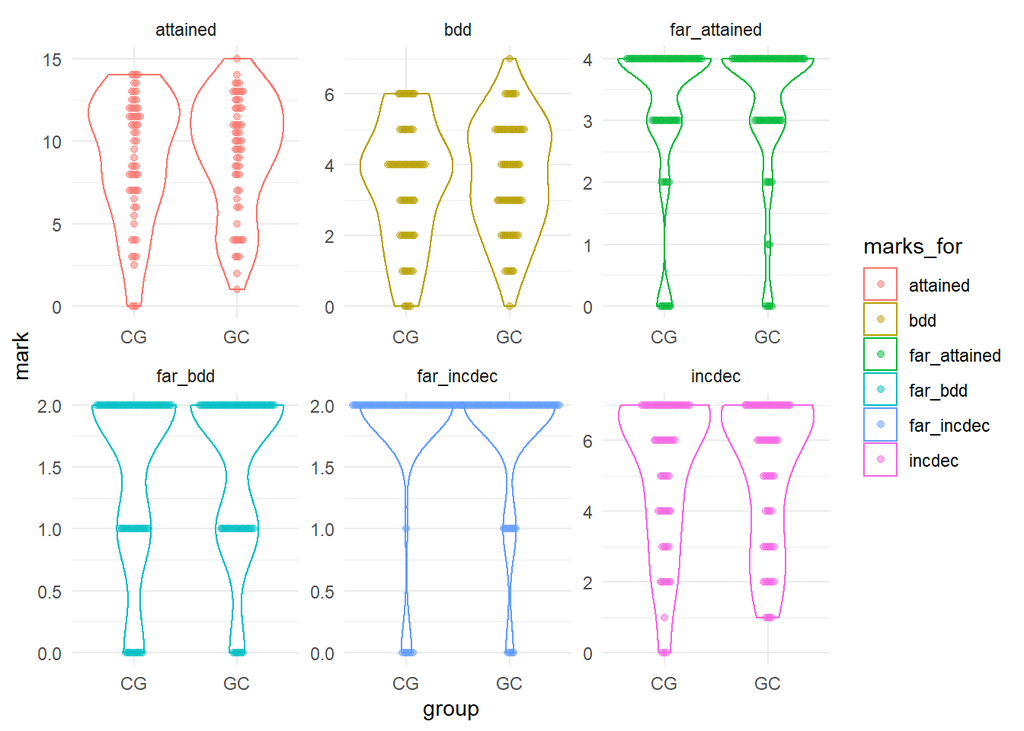

```r
detailed_scores_summary %>%
  pivot_longer(
    cols = contains("marks"),
    names_to = "marks_for",
    values_to = "mark",
    names_prefix = "marks_"
  ) %>%
  filter(marks_for != "available") %>%
  drop_na() %>%
  ggplot(aes(x = group, y = mark, colour = marks_for)) +
  geom_violin() +
  ggbeeswarm::geom_beeswarm(alpha = 0.5) +
  facet_wrap(~ marks_for, scales = "free")
```

```r
detailed_scores_summary %>%
  mutate(
    first_task = str_sub(group, start = 1, end = 1),
    later_tasks = str_sub(group, start = 3, end = 4)
  ) %>%
  group_by(overall_group) %>%
  mutate(n = n(), group_label = str_glue("{group} (n={n})")) %>%
  ungroup() %>%
  write_csv("data-clean/study2_detail.csv")
```

Here we carry out all the analyses to compare the results.

```r
compute_contrasts <- function(model) {
  # inspect draws from the model, and compute the contasts of interest
  contrasts <- model %>%
    tidy_draws() %>%
    select(starts_with("group"), sigma) %>%
    mutate(
      CGvsGC_contrast = `groupCG`-`groupGC`,
      CGvsGC_effect = CGvsGC_contrast / sigma,
    )
  contrasts_long <- contrasts %>%
    select(-starts_with("group")) %>%
    pivot_longer(
      cols = contains("vs"),
      names_to = "parameter",
      values_to = "est"
    ) %>%
    separate(parameter, into = c("comparison", "parameter"))

  contrasts_summary <- contrasts_long %>%
    group_by(comparison, parameter) %>%
    median_hdi(est) %>%
    ungroup() %>%
    mutate(formatted_hdi = str_glue("{round(est, 3)} ({.width*100}% HDI [{round(.lower, 3)}, {round(.upper, 3)}])"))

  return(list("contrasts_long" = contrasts_long, "contrasts_summary" = contrasts_summary))
}
```

```r
fit_model <- function(data) {
  stan_glm(
    formula = measure ~ 0 + group,
    data = data,
    seed = 123,
    refresh = 0 # to prevent messages about the MCMC iterations being printed
  )
}
all_comparisons <- tibble(
  measure = fct_inorder(c(
    "marks_attained",
    "marks_incdec",
    "marks_bdd",
    "marks_far_attained",
    "marks_far_incdec",
    "marks_far_bdd"
  ))
) %>%
  rowwise() %>%
  mutate(data = map(
    measure,
    ~ detailed_scores_summary %>% select(username, group, `measure` = all_of(measure))
  )) %>%
  ungroup() %>%
  mutate(measure_sd = map_dbl(data, ~ .x %>% summarise(marks_sd = sd(measure, na.rm = TRUE)) %>% deframe()))

all_model_fits <- all_comparisons %>%
  mutate(model = map(data, fit_model))

all_contrasts <- all_model_fits %>%
  mutate(contrasts = map(model, compute_contrasts)) %>%
  unnest_wider(contrasts)

all_contrasts %>%
  select(measure, contrasts_summary) %>%
  unnest(cols = contrasts_summary) %>%
  select(measure, comparison, parameter, formatted_hdi) %>%
  pivot_wider(
    names_from = parameter,
    values_from = formatted_hdi
  ) %>%
  basic_kable()
```

| measure | comparison | contrast | effect |
| --- | --- | --- | --- |
| marks_attained | CGvsGC | -0.243 (95% HDI [-1.594, 1.011]) | -0.064 (95% HDI [-0.401, 0.299]) |
| marks_incdec | CGvsGC | 0 (95% HDI [-0.774, 0.732]) | 0 (95% HDI [-0.339, 0.374]) |
| marks_bdd | CGvsGC | -0.201 (95% HDI [-0.766, 0.453]) | -0.12 (95% HDI [-0.481, 0.242]) |
| marks_far_attained | CGvsGC | -0.023 (95% HDI [-0.453, 0.402]) | -0.019 (95% HDI [-0.369, 0.344]) |
| marks_far_incdec | CGvsGC | 0.034 (95% HDI [-0.186, 0.236]) | 0.058 (95% HDI [-0.314, 0.398]) |
| marks_far_bdd | CGvsGC | -0.057 (95% HDI [-0.319, 0.189]) | -0.08 (95% HDI [-0.449, 0.264]) |

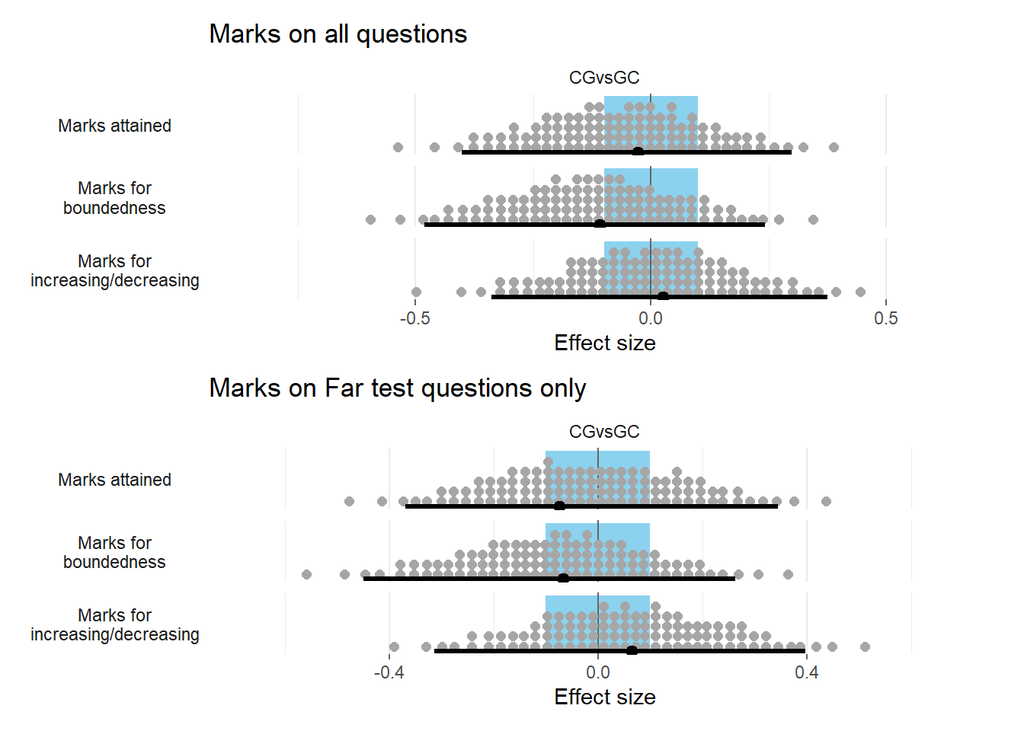

```r
contrast_data_for_plotting <- all_contrasts %>%
  select(measure, measure_sd, contrasts_long) %>%
  unnest(cols = c(contrasts_long)) %>%
  mutate(rope_width = case_when(parameter == "contrast" ~ 0.1*measure_sd, parameter == "effect" ~ 0.1)) %>%
  filter(parameter == "effect") %>%
  #mutate(comparison = fct_recode(comparison, "C* vs G*" = "CvsG",  "*CG vs *GC" = "CGvsGC")) %>%
  mutate(far_measure = str_detect(measure, "far")) %>%
  mutate(
    measure = str_remove_all(measure, "marks_|far_"),
    measure = str_replace_all(
       measure,
       c(
         "attained" = "Marks attained",
         "incdec" = "Marks for\nincreasing/decreasing",
         "bdd" = "Marks for\nboundedness"
       )
     )
  )


plot_all <- contrast_data_for_plotting %>%
  filter(!far_measure) %>%
  ggplot(aes(x = est, y = 0)) +
  geom_rect(aes(xmin = -rope_width, xmax = rope_width), ymin = 0, ymax = 1, fill = "skyblue", alpha = 0.1) +
  geom_vline(xintercept = 0, colour = "grey40") +
  stat_dotsinterval(
    point_interval = mode_hdi,
    .width = .95,
    slab_size = 0,
    quantiles = 100
  ) +
  scale_y_continuous(NULL, breaks = NULL) +
  expand_limits(x = c(-0.1, 0.1)) +
  xlab("Effect size") +
  facet_grid(cols = vars(comparison), rows = vars(measure), scales = "free_x", switch = "y") +
  theme(#panel.grid = element_blank(),
        axis.ticks = element_line(color = "grey40"),
        strip.text.y.left = element_text(angle = 0)
        )

plot_far_only <- contrast_data_for_plotting %>%
  filter(far_measure) %>%
  ggplot(aes(x = est, y = 0)) +
  geom_rect(aes(xmin = -rope_width, xmax = rope_width), ymin = 0, ymax = 1, fill = "skyblue", alpha = 0.1) +
  geom_vline(xintercept = 0, colour = "grey40") +
  stat_dotsinterval(
    point_interval = mode_hdi,
    .width = .95,
    slab_size = 0,
    quantiles = 100
  ) +
  scale_y_continuous(NULL, breaks = NULL) +
  expand_limits(x = c(-0.1, 0.1)) +
  xlab("Effect size") +
  facet_grid(cols = vars(comparison), rows = vars(measure), scales = "free_x", switch = "y") +
  theme(#panel.grid = element_blank(),
        axis.ticks = element_line(color = "grey40"),
        strip.text.y.left = element_text(angle = 0)
        )

(plot_all + labs(title = "Marks on all questions")) / (plot_far_only + labs(title = "Marks on Far test questions only"))
```

## Main comparison

Since the pattern of results is basically the same for all outcome measures, we focus on `marks_attained` across all questions.

```r
model <- (all_model_fits %>% filter(measure == "marks_attained") %>% pull(model))[[1]]
rope_width <- 0.1*(all_model_fits %>% filter(measure == "marks_attained") %>% pull(measure_sd))[[1]]
```

```r
means <- modelbased::estimate_means(model, ci = ci_width, centrality = "median", ci_method = "hdi")
```

```
## We selected `at = c("group")`.
```

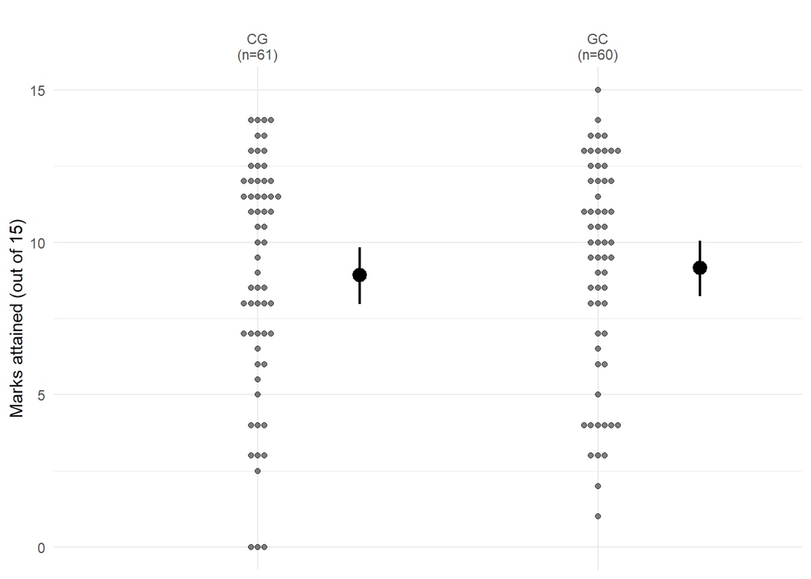

```r
detailed_scores_summary %>%
  ggplot(aes(x = group, y = marks_attained)) +
  ggbeeswarm::geom_beeswarm(alpha = 0.5) +
  geom_pointrange(data = means, aes(x = group, y = Mean, ymin = CI_low, ymax = CI_high),
                  position = position_nudge(x = 0.3),
                  size = 0.8) +
  scale_x_discrete("", labels = detailed_scores_summary %>% filter(!is.na(marks_attained)) %>% group_by(group) %>% summarise(group_label = str_glue("{group}\n(n={n()})"), .groups = "drop") %>% deframe(), position = "top") +
  scale_y_continuous("Marks attained (out of 15)") +
  theme(legend.position = "none")
```

```r
ggsave("figs/FIG_study2_marks_attained.eps", device = cairo_ps, width = 12, height = 7, units = "cm")
```

```r
tab1 <- detailed_scores_summary %>%
  group_by(group) %>%
  summarise(
    n = sum(!is.na(marks_attained)),
    mean = mean(marks_attained, na.rm = TRUE),
    sd = sd(marks_attained, na.rm = TRUE),
    .groups = "drop"
  ) %>%
  # group is of type "glue" so force it to be a string in order to join on it
  mutate(group = paste(group)) %>%
  left_join(means, by = "group") %>%
  # show the HDI but not the estimated mean since that's superfluous
  select(-Mean) %>%
  mutate(estimate_hdi = str_glue("[{round(CI_low, 3)}, {round(CI_high, 3)}]"), .keep = "unused")

tab1 %>%
  basic_kable(caption = "Study 2 group means", digits = 3)
```

Study 2 group means

| group | n | mean | sd | estimate_hdi |
| --- | --- | --- | --- | --- |
| CG | 61 | 8.934 | 3.823 | [7.974, 9.825] |
| GC | 60 | 9.167 | 3.565 | [8.228, 10.053] |

```r
tab1 %>%
  basic_kable(caption = "Study 2 group means", digits = 3, booktabs = T, format = "latex") %>%
  cat()
```

```
## \begin{table}
##
## \caption{\label{tab:unnamed-chunk-11}Study 2 group means}
## \centering
## \begin{tabular}[t]{lrrrl}
## \toprule
## group & n & mean & sd & estimate\_hdi\\
## \midrule
## CG & 61 & 8.934 & 3.823 & {}[7.974, 9.825]\\
## GC & 60 & 9.167 & 3.565 & {}[8.228, 10.053]\\
## \bottomrule
## \end{tabular}
## \end{table}
```

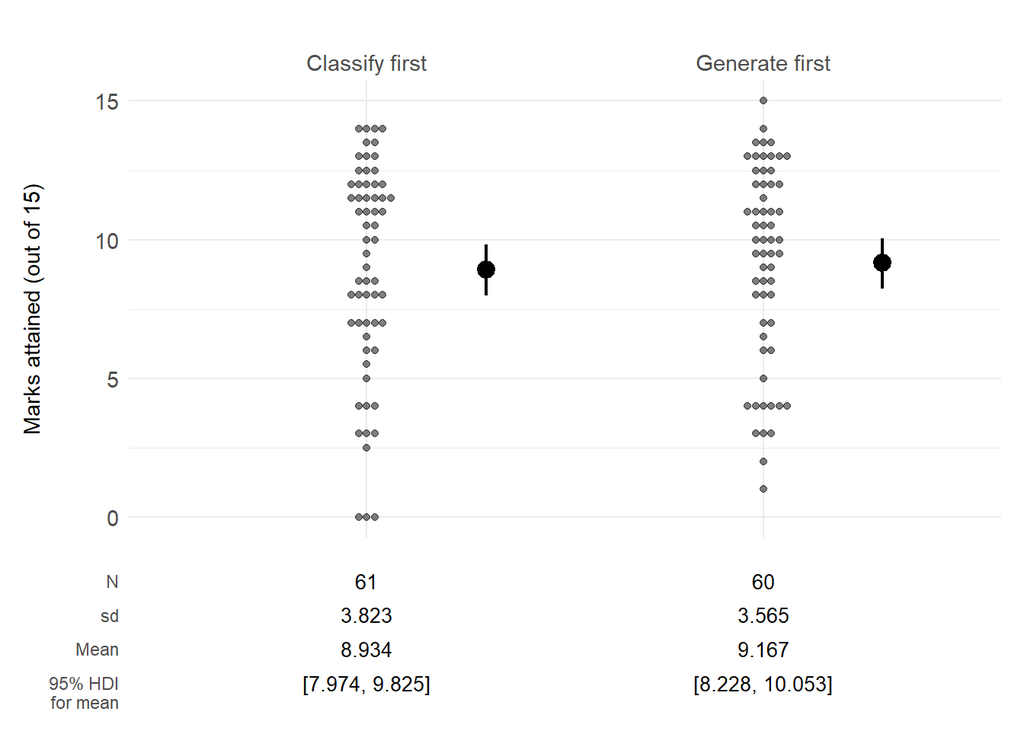

```r
# inspired by https://stackoverflow.com/questions/61977439/table-below-x-axis-in-ggplot
p1 <- detailed_scores_summary %>%
  ggplot(aes(x = group, y = marks_attained)) +
  ggbeeswarm::geom_beeswarm(alpha = 0.5) +
  geom_pointrange(data = means, aes(x = group, y = Mean, ymin = CI_low, ymax = CI_high),
                  position = position_nudge(x = 0.3),
                  size = 0.8) +
  #scale_x_discrete("", labels = detailed_scores_summary %>% select(group) %>% distinct(), position = "top") +
  scale_x_discrete("", labels = c("CG" = "Classify first", "GC" = "Generate first"), position = "top") +
  scale_y_continuous("Marks attained (out of 15)") +
  theme(legend.position = "none", axis.text = element_text(size = 11))

p2 <- tab1 %>%
  mutate(group_label = str_glue("{group}\n(n={n})")) %>%
  mutate(
    n = str_glue("{n}"),
    mean = str_glue("{round(mean, digits = 3)}"),
    sd = str_glue("{round(sd, digits = 3)}")
  ) %>%
  pivot_longer(c(n, mean, sd, estimate_hdi), names_to = "layer", values_to = "label") %>%
  mutate(layer = fct_relevel(layer, c("n", "sd", "mean", "estimate_hdi")) %>% fct_rev()) %>%
  #filter(layer != "n") %>%
  ggplot(aes(x = group, y = layer, label = label)) +
  geom_text(size = 10 * 5/14) +
  labs(y = "", x = NULL) +
  scale_y_discrete(labels = c("n" = "N", "mean" = "Mean", "estimate_hdi" = "\n95% HDI\nfor mean")) +
  theme_minimal() +
  theme(axis.line = element_blank(), axis.ticks = element_blank(), axis.text.x = element_blank(),
        panel.grid = element_blank(), strip.text = element_blank())

p1 / p2 +  plot_layout(heights = c(8, 2.5))
```

```r
ggsave("figs/FIG_study2_marks_attained_with_table.eps", device = cairo_ps, width = 10, height = 10, units = "cm")
```

```r
contrasts <- model %>%
  tidy_draws() %>%
  select(starts_with("group"), sigma) %>%
  mutate(
    CGvsGC_contrast = `groupCG`-`groupGC`,
    CGvsGC_effect = CGvsGC_contrast / sigma,
  )
contrasts_long <- contrasts %>%
  select(-starts_with("group")) %>%
  pivot_longer(
    cols = contains("vs"),
    names_to = "parameter",
    values_to = "est"
  ) %>%
  separate(parameter, into = c("contrast", "parameter"))

contrasts_summary <- contrasts_long %>%
  group_by(contrast, parameter) %>%
  median_hdi(est) %>%
  ungroup() %>%
  mutate(formatted_hdi = str_glue("{round(est, 3)} ({.width*100}% HDI [{round(.lower, 3)}, {round(.upper, 3)}])"))

contrasts_summary %>%
  select(measure = contrast, parameter, formatted_hdi) %>%
  pivot_wider(
    names_from = parameter,
    values_from = formatted_hdi
  ) %>%
  basic_kable()
```

| measure | contrast | effect |
| --- | --- | --- |
| CGvsGC | -0.243 (95% HDI [-1.594, 1.011]) | -0.064 (95% HDI [-0.401, 0.299]) |

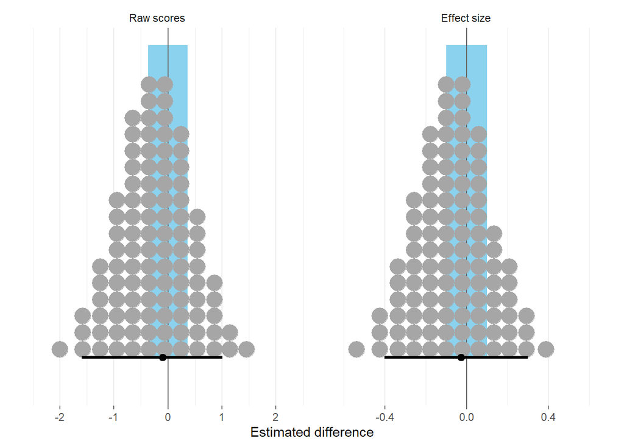

```r
p_diffs <- contrasts_long %>%
  mutate(rope_width = case_when(parameter == "contrast" ~ rope_width, parameter == "effect" ~ 0.1)) %>%
  mutate(parameter = fct_recode(parameter, "Raw scores" = "contrast",  "Effect size" = "effect")) %>%
  ggplot(aes(x = est, y = 0)) +
  geom_rect(aes(xmin = -rope_width, xmax = rope_width), ymin = 0, ymax = 1, fill = "skyblue", alpha = 0.1) +
  geom_vline(xintercept = 0, colour = "grey40") +
  stat_dotsinterval(
    point_interval = mode_hdi,
    .width = .95,
    slab_size = 0,
    quantiles = 100
  ) +
  scale_y_continuous(NULL, breaks = NULL) +
  expand_limits(x = c(-0.1, 0.1)) +
  expand_limits(y = c(-0.1)) +
  xlab("Estimated difference") +
  facet_grid(cols = vars(parameter), scales = "free_x", switch = "y") +
  theme(#panel.grid = element_blank(),
        axis.ticks = element_line(color = "grey40"),
        strip.text.y.left = element_text(angle = 0)
        )
p_diffs
```

```r
ggsave("figs/FIG_study2_marks_attained_effect.eps", device = cairo_ps, width = 14, height = 4, units = "cm")
```